# Fitting a Densely Observed Mira Light Curve

## The Gaussian process model

Let $y_i$ be the magnitude of a variable star observed at time $t_i$ (in units of days) with uncertainty $\sigma_i$. The data set for this object, obtained as part of a time-series survey with $n$ epochs is $\{(t_i,y_i,\sigma_i)\}_{i=1}^n$.

Suppose the data $\{(t_i,y_i,\sigma_i)\}_{i=1}^n$ is modeled by
$$y_i = g(t_i) + \sigma_i\epsilon_i\,$$
where $g(t_i)$ is the light curve signal and the $\epsilon_i\sim N(0,1)$ is independent with other $\epsilon_j$’s.

The light curve signal $g(t_i)$ is further decomposed into four parts. We have
$$g(t) = m + l(t) + q(t) + h(t)\ ,$$
where $m$ is the long run average magnitude, $l(t)$ is the long-term (low-frequency) trend across different cycles, $q(t)$ is the periodic term, and $h(t)$ is small-scale (high-frequency) variability within each cycle. The latter three terms are modeled by the Gaussian process with different kernels. In particular, we use the squared exponential kernel
$$k_l(t_1,t_2) = \theta_1^2 \exp(-\frac{1}{2}\frac{(t_1-t_2)^2}{\theta_2^2})$$
for $l(t)$, another squared exponential kernel $k_h(t_1,t_2) = \theta_6^2 \exp(-\frac{1}{2}\frac{(t_1-t_2)^2}{\theta_7^2})$ for $h(t)$, and lastly a periodic kernel
$$k_q(t_1,t_2) = \theta_3^2 \exp(-\frac{1}{2}\frac{(t_1-t_2)^2}{\theta_4^2}
- \frac{2\sin^2(2\pi f(t_1-t_2))}{\theta_5^2} )$$
for $q(t)$. Note the periodical kernel allows the light curve amplitude to change across cycles. We have a total number of seven parameters to fit, and we put them in a vector $\boldsymbol{\theta} = (\theta_1,\theta_2, \cdots, \theta_7)^T$.

## One OGLE Mira Light Curve

In this example, the above Gaussian process model is fitted on a densely observed Mira light curve.

```r
library(varStar)
starObs = read.table("./OGLE-LMC-LPV-00055.dat")
obsJD = starObs$V1
obsMag = starObs$V2
obsSigma = starObs$V3
head(starObs)
```

```
##         V1     V2    V3
## 1 2171.860 16.058 0.007
## 2 2183.820 16.303 0.009
## 3 2184.819 16.258 0.009
## 4 2188.870 16.317 0.009
## 5 2191.781 16.350 0.008
## 6 2200.800 16.426 0.008
```

The function `plotStarObs()` will plot the light curve data. The default label of y-axis is *I [mag]*, and the default lable of x-axis is *Julian Data - 2450000*. The labels could be changed via the function parameter `xlab` and `ylab`.

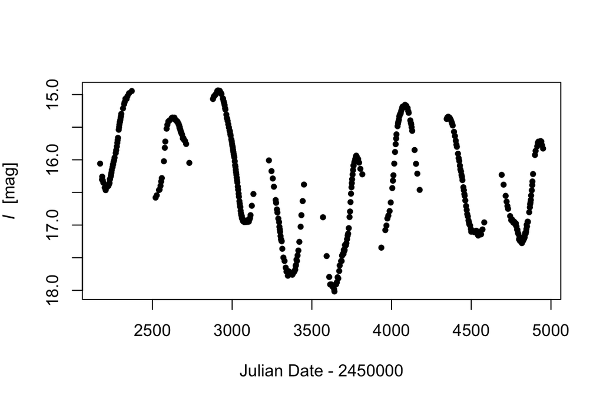

```r
plotStarObs(obsJD,obsMag,obsSigma)
```

A modeling object of class `gpModel` is created by the `new()` function. The numerical vectors of Julia date, magnitude and sigma are provided as additional parameters. The true period of the light curve is 290.9 days. This value is used to set the frequency.

```r
p0 = 290.9 ## true period of the light curve
modelObj = new(gpModel, obsJD, obsMag, obsSigma)
modelObj$set_freq(1/p0)
```

The function `fitComplexGP()` fit the model with 5 randomly initialized paramter $\boldsymbol{\theta}$’s. The best fitting result (with maximum likelihood) is kept.

```r
set.seed(100)
modelObj = fitComplexGP(modelObj)
```

After the model fitting, we could obtain various components of the light curve signal $g(t)$. The function `modelObj$gp_predict(tt, compoentI)` predict light curve component at Julian data `tt`. The second parameter `componentI` could be set to one of the values 0,1,2,3. Setting `compoentI = 0` returns the predicted $g(t)$ value, `compoentI = 1` returns the predicted $m + l(t)$ value, `compoentI = 2` returns the predicted $m +q(t)$ value, and lastly `compoentI = 3` returns the predicted $m + h(t)$ value. The value $m$ is simply estimated by the average of all magnitude values $y_i$’s.

```r
tt = c(3500, 4000)
modelObj$gp_predict(tt, 0) ## fitted value at JD, tt
```

```
##          [,1]
## [1,] 16.15684
## [2,] 16.55768
```

The function `plotAllComponents()` is convenient to plot all components of the fitted model.

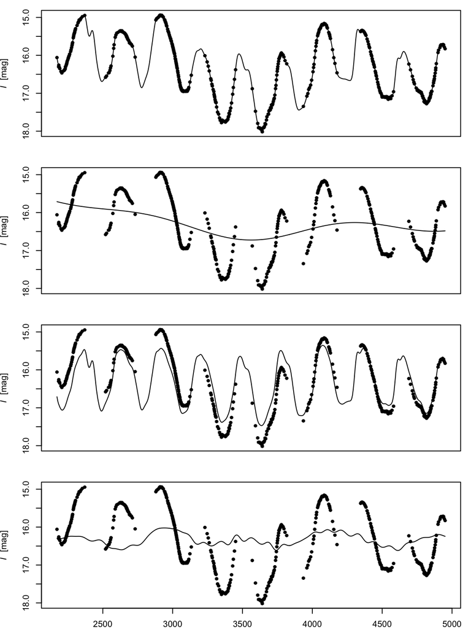

```r
plotAllComponents(modelObj)
```